# Completed randomized design

Author

Affiliation

Undergrad Hernandes Peres

[Biometrics Lab.](https://biometria.ufv.br/)

[figure not shown]

[figure not shown]

To compare the productivity of four corn varieties, an agronomist took twenty similar experimental units and randomly assigned each of the four varieties to five of them. Based on the experimental data provided below, is it possible to conclude that there is a significant difference between the varieties in terms of productivity, using a 5% significance level?

```r
data <- data.frame(rep = rep(1:5, each=4),
                   trat = factor(rep(c("A", "B", "C", "D"),
                                        times=5)),
                   yield = c(25, 31, 22, 33,
                             26, 25, 26, 29,
                             20, 28, 28, 31,
                             23, 27, 25, 34,
                             21, 24, 29, 28))

knitr::kable(data)
```

| rep | trat | yield |
| --- | --- | --- |
| 1 | A | 25 |
| 1 | B | 31 |
| 1 | C | 22 |
| 1 | D | 33 |
| 2 | A | 26 |
| 2 | B | 25 |
| 2 | C | 26 |
| 2 | D | 29 |
| 3 | A | 20 |
| 3 | B | 28 |
| 3 | C | 28 |
| 3 | D | 31 |
| 4 | A | 23 |
| 4 | B | 27 |
| 4 | C | 25 |
| 4 | D | 34 |
| 5 | A | 21 |
| 5 | B | 24 |
| 5 | C | 29 |
| 5 | D | 28 |

### 1. Creating sketch

When we have a daily chore or an activity that is performed frequently, we can create functions to save time and reduce repetitive work.

By utilizing the syntax `function(x) {}`, we can define the behavior we want to automate.

In this example, I created a function to combine all positions between the number of rows and columns using the `expand.grid()` function. Then, to follow one of the principles of experimental design — **randomization** — I used the `sample()` function to randomly assign positions within the created object.

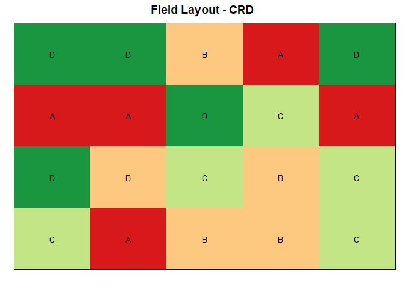

```
$data
   rep trat yield col row
1    1    A    25   1   3
2    1    B    31   4   2
3    1    C    22   5   2
4    1    D    33   1   4
5    2    A    26   2   3
6    2    B    25   2   2
7    2    C    26   3   2
8    2    D    29   1   2
9    3    A    20   5   3
10   3    B    28   3   1
11   3    C    28   4   3
12   3    D    31   2   4
13   4    A    23   2   1
14   4    B    27   3   4
15   4    C    25   5   1
16   4    D    34   5   4
17   5    A    21   4   4
18   5    B    24   4   1
19   5    C    29   1   1
20   5    D    28   3   3
```

```r
set.seed(10)

field_layout(data = data,
             n_row = 4,
             n_col = 5,
             design = "DIC")
```

### 2. ANOVA Analysis

As we have seen, by using the `aov()` function, we can model the ANOVA for the *yield* through the treatment effects, which correspond to the *trat*.

```r
fit <- aov(yield ~ trat, data = data)

anova(fit)
```

```
Analysis of Variance Table

Response: yield
          Df Sum Sq Mean Sq F value   Pr(>F)
trat       3 163.75  54.583  7.7976 0.001976 **
Residuals 16 112.00   7.000
---
Signif. codes:  0 '***' 0.001 '**' 0.01 '*' 0.05 '.' 0.1 ' ' 1
```

The CRD statistical model is the simplest one and is assumed to be equal to:
$$y_{ik}=\mu+\tau_i+\varepsilon_{ik}$$
**Where:**

- $y_{ik}:$Is the value of the response variable observed in the k-th repetition of the i-th level of the factor veing tested;
- $\mu:$Is the mean value of the response variable;
- $\tau_i:$ Is the effect of the i-th level of the tested factor;
- $\varepsilon_{ik}:$ Is the experimental error of the observed value $y_{ik}$;

### 3. Residual Analysis

Residual analysis is performed because the assumptions of ANOVA are related to the residual values.

Remember the assumptions of ANOVA:

- **Additivity:** The effects of the different factors in the model are additive, meaning they do not interact in a non-linear way.
- **Normality of residuals:** The residuals should follow a normal distribution.
- **Homogeneity of variance:** The variance of residuals should be constant across groups (also known as homoscedasticity).
- **Independence of observations:** The observations are independent of each other.

When one of these assumptions is violated, the reliability of all parametric tests becomes compromised. Additionally, errors such as Type I and Type II can influence the conclusions drawn about treatment effects.

Then, the analysis ended up being reduced to mere mathematical data processing.

```r
residuals <- fit$residuals
mean_res <- mean(residuals)
sd_res <- sd(residuals)
```

### 4. Normality Tests

Installing and loading the `"nortest"` package, which is used for a trat of normality tests, such as:

- Kolmogorov-Smirnov Tests - `ks.test()`
- Lilliefors Test - `lillie.test()`
- Cramer-von Mises test - `cvm.test()`
- Shapiro-Wilk Normality Test - `shapiro.test()`
- Shapiro-Francia test - `sf.test()`
- Anderson-Darling test - `ad.test()`

At the nomality tests, what we are testing are the hypotesis of:

- $H_0:\text{Residuals follow a normal distribuition}$
- $H_a:\text{Residual do not follow a normal distribuition}$

```r
# install.packages(nortest)
library(nortest)

t1 <- ks.test(residuals, "pnorm", mean_res, sd_res)
t2 <- lillie.test(residuals)
t3 <- cvm.test(residuals)
t4 <- shapiro.test(residuals)
t5 <- sf.test(residuals)
t6 <- ad.test(residuals)
```

Taking the **name**, **statistics**, and **p-values** from each performed normality test and organizing them into a data frame.

```r
tests <- c(t1$method, t2$method, t3$method,
           t4$method, t5$method, t6$method)
statistics <- c(t1$statistic, t2$statistic, t3$statistic,
                t4$statistic, t5$statistic, t6$statistic)
p_values <- c(t1$p.value, t2$p.value, t3$p.value,
              t4$p.value, t5$p.value, t6$p.value)
```

```r
results <- data.frame(Test = tests, Statistic = statistics, P_Value = p_values)
knitr::kable(results)
```

| Test | Statistic | P_Value |
| --- | --- | --- |
| Asymptotic one-sample Kolmogorov-Smirnov test | 0.1449605 | 0.7946673 |
| Lilliefors (Kolmogorov-Smirnov) normality test | 0.1449605 | 0.3302557 |
| Cramer-von Mises normality test | 0.0713501 | 0.2545624 |
| Shapiro-Wilk normality test | 0.9396228 | 0.2358736 |
| Shapiro-Francia normality test | 0.9539271 | 0.3652357 |
| Anderson-Darling normality test | 0.4642887 | 0.2280122 |

### 5. Homoscedasticity Tests

Through the homoscedasticity tests, we aim to verify whether the residual effects have impacted the equality across all treatments.

Then the hypotesis tested are:

- $H_0: \text{The experimental residuals have homogeneous variance}$
- $H_a: \text{The experimental residuals do not have homogeneous variance}$

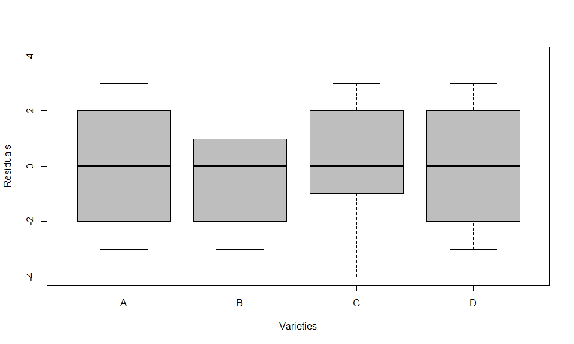

```r
boxplot(residuals ~ data$trat,
        col="gray", ylab="Residuals", xlab="Varieties")
```

Installing and loading the package `lawstat` we can have acess to the function `levene.test()` to perform **Levene’s Test of Equality of Variances**

```r
# install.packages("lawstat")
library(lawstat)
levene.test(residuals, data$trat)
```

```
    Modified robust Brown-Forsythe Levene-type test based on the absolute
    deviations from the median

data:  residuals
Test Statistic = 5.144e-30, p-value = 1
```

### 6. Independence Check

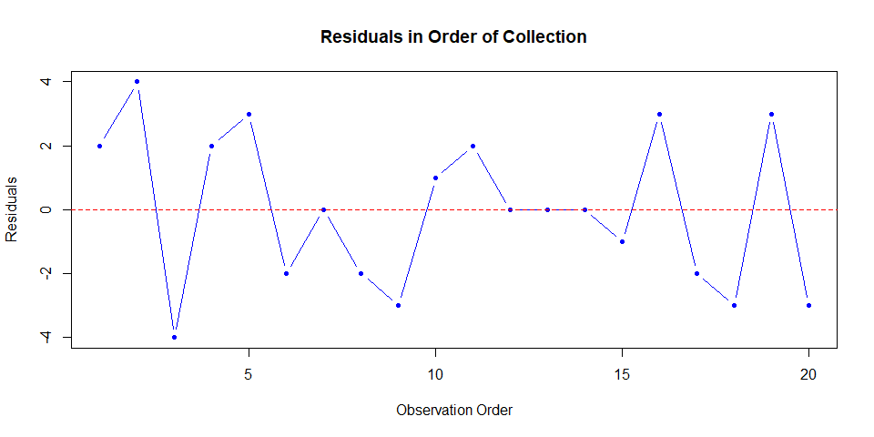

```r
plot(residuals,
     type = "b",
     pch = 20,
     col = "blue",
     xlab = "Observation Order",
     ylab = "Residuals",
     main = "Residuals in Order of Collection")
abline(h = 0, col = "red", lty = 2)
```

### 7. Multiple Comparisons

Before proceeding with CMD analysis, we have to remember the experimental principles, which are:

- $\text{Repetition}$
- $\text{Casualisation}$
- $\text{Local control (if it is needed)}$

By installing and loading the package `ExpDes` we can speed up the process, utilizing `dic()` for and Completed Ramdomized Design (CMD)

- is used when all experiment condition are homogeneous (environment, materials and others)
- Treatments are sample at ramdom without any restriction
- Usually it is used at laboratory conditions

$\text{Just remembering how to compute it manually:}$
$$\begin{array}{|c|c|c|c|c|}
\hline
\text{Repetition} & \text{A} & \text{B} & \text{C} & \text{D} \\
\hline
1 & 25 & 31 & 22 & 33 \\
2 & 26 & 25 & 26 & 29 \\
3 & 20 & 28 & 28 & 31 \\
4 & 23 & 27 & 25 & 34 \\
5 & 21 & 24 & 29 & 28 \\
\hline
\text{Totais} & 115 & 135 & 130 & 155 \\
\text{Médias} & 23 & 27 & 26 & 31 \\
\hline
\end{array}$$
$$SQ_{total} = \sum_{ik}y_{ik}^2-C \quad \text{where} \quad C=\frac{(\sum_{ik}y_{ik})^2}{n} = \frac{535^2}{20}=14.311,25$$
$$SQ_{total}=25^2+26^2+...+28^2-14.311,25\\
=14.587,00-14.311,25=275,75$$
$$SQ_{trat} = (\frac{115^2}{5}+\frac{135^2}{5}+\frac{130^2}{5}+\frac{155^2}{5})-14.311,25\\=14.475,00-14.311,25=163,75$$
$$SQ_{res}=SQ_{total}-SQ_{trat}$$
$$SQ_{res}=275,75-163,75=112,00$$

```r
# install.packages("ExpDes.pt")
library(ExpDes.pt)

dic(data$trat, data$yield, quali = TRUE,
    mcomp = "lsdb", hvar= "bartlett", sigT = 0.05, sigF = 0.05)
```

```
------------------------------------------------------------------------
Quadro da analise de variancia
------------------------------------------------------------------------
           GL     SQ     QM     Fc     Pr>Fc
Tratamento  3 163.75 54.583 7.7976 0.0019756
Residuo    16 112.00  7.000
Total      19 275.75
------------------------------------------------------------------------
CV = 9.89 %

------------------------------------------------------------------------
Teste de normalidade dos residuos ( Shapiro-Wilk )
Valor-p:  0.2358736
De acordo com o teste de Shapiro-Wilk a 5% de significancia, os residuos podem ser considerados normais.
------------------------------------------------------------------------

------------------------------------------------------------------------
Teste de homogeneidade de variancia
valor-p:  0.7825358
De acordo com o teste de bartlett a 5% de significancia, as variancias podem ser consideradas homogeneas.
------------------------------------------------------------------------

Teste t de Bonferroni (LSD protegido)
------------------------------------------------------------------------
Grupos  Tratamentos  Medias
a    D   31
ab   B   27
ab   C   26
 b   A   23
------------------------------------------------------------------------
```

### 8. CRD - Unbalanced Data

```r
remove(list=ls())
source("ExperimentalDesignFunction.R")
```

```r
data_unbalanced <- read.table("DataUnbalance.txt", head=TRUE)
data_unbalanced$trat <- factor(data_unbalanced$trat)

n <- length(data_unbalanced$result)
```

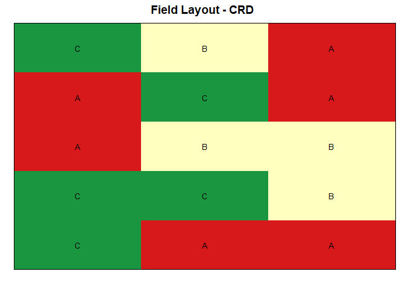

```r
set.seed(7)
layout <- field_layout(data = data_unbalanced,
             n_col = 3,
             n_row = 5,
             design = "DIC")
layout$plot
```

```r
knitr::kable(layout$data)
```

| coleta | trat | rep | result | col | row |
| --- | --- | --- | --- | --- | --- |
| 7 | A | 1 | 29 | 1 | 4 |
| 11 | A | 2 | 27 | 3 | 1 |
| 9 | A | 3 | 31 | 3 | 4 |
| 5 | A | 4 | 29 | 1 | 3 |
| 10 | A | 5 | 32 | 2 | 1 |
| 6 | A | 6 | 30 | 3 | 5 |
| 12 | B | 1 | 27 | 3 | 2 |
| 1 | B | 2 | 27 | 2 | 3 |
| 14 | B | 3 | 30 | 2 | 5 |
| 2 | B | 4 | 28 | 3 | 3 |
| 4 | C | 1 | 30 | 1 | 5 |
| 13 | C | 2 | 30 | 2 | 4 |
| 3 | C | 3 | 31 | 2 | 2 |
| 15 | C | 4 | 27 | 1 | 2 |
| 8 | C | 5 | 29 | 1 | 1 |

```r
fit_unbalanced <- aov(result ~ trat, data = data_unbalanced)
anova(fit_unbalanced)
```

```
Analysis of Variance Table

Response: result
          Df Sum Sq Mean Sq F value Pr(>F)
trat       2  7.200  3.6000  1.4148 0.2807
Residuals 12 30.533  2.5444
```

```r
residuals_unbalanced <- fit_unbalanced$residuals
mean_res_unbalanced <- mean(residuals_unbalanced)
sd_res_unbalanced <- sd(residuals_unbalanced)
```

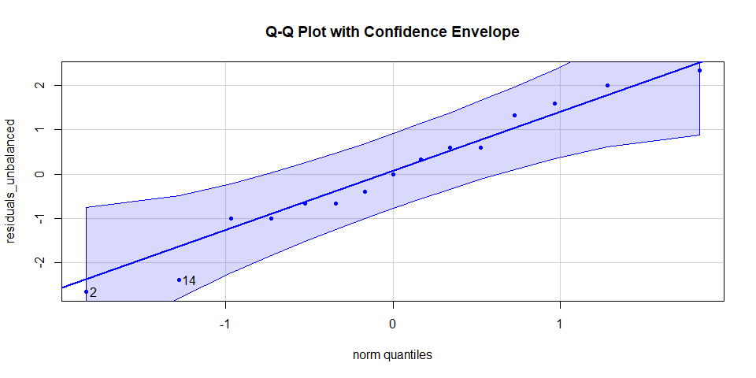

```
[1]  2 14
```

```r
# install.packages("car")
library(car)

qqPlot(residuals_unbalanced,
       main = "Q-Q Plot with Confidence Envelope",
       col = "blue",
       pch = 20,
       envelope = 0.95)  # 95% confidence envelope
```

```r
library(nortest)
t1 <- ks.test(residuals_unbalanced,
              "pnorm", mean_res_unbalanced, sd_res_unbalanced)
t2 <- lillie.test(residuals_unbalanced)
t3 <- cvm.test(residuals_unbalanced)
t4 <- shapiro.test(residuals_unbalanced)
t5 <- sf.test(residuals_unbalanced)
t6 <- ad.test(residuals_unbalanced)
```

```r
tests <- c(t1$method, t2$method, t3$method, t4$method, t5$method, t6$method)
statistics <- c(t1$statistic,
                t2$statistic,
                t3$statistic,
                t4$statistic,
                t5$statistic,
                t6$statistic)

p_values <- c(t1$p.value, t2$p.value, t3$p.value,
              t4$p.value, t5$p.value, t6$p.value)
```

```r
results <- data.frame(Test = tests,
                      Statistic = statistics,
                      P_Value = p_values)

knitr::kable(results)
```

| Test | Statistic | P_Value |
| --- | --- | --- |
| Asymptotic one-sample Kolmogorov-Smirnov test | 0.1158260 | 0.9878456 |
| Lilliefors (Kolmogorov-Smirnov) normality test | 0.1158260 | 0.8496216 |
| Cramer-von Mises normality test | 0.0257102 | 0.8895194 |
| Shapiro-Wilk normality test | 0.9662760 | 0.7996015 |
| Shapiro-Francia normality test | 0.9750670 | 0.8623185 |
| Anderson-Darling normality test | 0.1994927 | 0.8575075 |

```r
fit_final <- aov(result ~ trat, data = data_unbalanced)
anova(fit_final)
```

```
Analysis of Variance Table

Response: result
          Df Sum Sq Mean Sq F value Pr(>F)
trat       2  7.200  3.6000  1.4148 0.2807
Residuals 12 30.533  2.5444
```

```r
library(ExpDes.pt)
dic(data_unbalanced$trat, data_unbalanced$result, quali = TRUE, mcomp = "tukey", sigT = 0.05, sigF = 0.05)
```

```
------------------------------------------------------------------------
Quadro da analise de variancia
------------------------------------------------------------------------
           GL     SQ     QM     Fc   Pr>Fc
Tratamento  2  7.200 3.6000 1.4148 0.28073
Residuo    12 30.533 2.5444
Total      14 37.733
------------------------------------------------------------------------
CV = 5.48 %

------------------------------------------------------------------------
Teste de normalidade dos residuos ( Shapiro-Wilk )
Valor-p:  0.7996015
De acordo com o teste de Shapiro-Wilk a 5% de significancia, os residuos podem ser considerados normais.
------------------------------------------------------------------------

------------------------------------------------------------------------
Teste de homogeneidade de variancia
valor-p:  0.9172462
De acordo com o teste de bartlett a 5% de significancia, as variancias podem ser consideradas homogeneas.
------------------------------------------------------------------------

De acordo com o teste F, as medias nao podem ser consideradas diferentes.
------------------------------------------------------------------------
  Niveis   Medias
1      A 29.66667
2      B 28.00000
3      C 29.40000
------------------------------------------------------------------------
```